# Lab 09 Natural Language Toolkit (NLTK)

11/02/2023

Overview:  
-NLTK Install  
-NLTK Data Sets  
-Tokenization  
-NLTK examples

**Natural Language Toolkit (NLTK)** is a popular Python Natural Language Python library.  
**Reference book on NLTK and discussion on NLP:**  
http://www.nltk.org/book/  
http://www.nltk.org/book/ch01.html

http://www.nltk.org/install.html Install nltk from the command prompt:  
pip install --user -U nltk  
pip install --upgrade nltk # to check for upgrades Note: You will need numpy installed too. This should already be installed with your Anaconda install.

```python
!pip install --upgrade nltk
```

```
WARNING: Error parsing requirements for tensorflow-estimator: [Errno 2] No such file or directory: '/Users/shiveshrajsahu/anaconda3/lib/python3.10/site-packages/tensorflow_estimator-2.12.0.dist-info/METADATA'
```

```python
!pip install --user -U nltk
```

```
WARNING: Error parsing requirements for tensorflow-estimator: [Errno 2] No such file or directory: '/Users/shiveshrajsahu/anaconda3/lib/python3.10/site-packages/tensorflow_estimator-2.12.0.dist-info/METADATA'
```

```python
# Check if NLTK installed correctly
import nltk
print(nltk.__version__)
```

```
3.8.1
```

```python
# To download all the data associated with NLTK:
# Download takes a while!
nltk.download('all')
#Locate where you nltk_data was set up from your download
#Mine is in: C:\Users\clbustam\AppData\Roaming\nltk_data
```

```
True
```

The Brown Corpus was the first million-word electronic corpus of English, created in 1961 at Brown University. This corpus contains text from 500 sources, and the sources have been categorized by genre, such as news, editorial, and so on. 1.1 gives an example of each genre (for a complete list, see http://icame.uib.no/brown/bcm-los.html).

You can access a corpus as a list of words or a list of sentences (where each sentence is itself just a list of words). We can optionally specify particular categories or files to read.

```python
from nltk.corpus import brown
brown.words(categories='news')
```

```
['The', 'Fulton', 'County', 'Grand', 'Jury', 'said', ...]
```

```python
brown.categories()
```

```
['adventure',
 'belles_lettres',
 'editorial',
 'fiction',
 'government',
 'hobbies',
 'humor',
 'learned',
 'lore',
 'mystery',
 'news',
 'religion',
 'reviews',
 'romance',
 'science_fiction']
```

Each section of the Brown Corpus is defined as:  
ID File Genre Description  
A16 ca16 news Chicago Tribune: Society Reportage  
B02 cb02 editorial Christian Science Monitor: Editorials  
C17 cc17 reviews Time Magazine: Reviews  
D12 cd12 religion Underwood: Probing the Ethics of Realtors  
E36 ce36 hobbies Norling: Renting a Car in Europe  
F25 cf25 lore Boroff: Jewish Teenage Culture  
G22 cg22 belles_lettres Reiner: Coping with Runaway Technology  
H15 ch15 government US Office of Civil and Defence Mobilization: The Family Fallout Shelter  
J17 cj19 learned Mosteller: Probability with Statistical Applications  
K04 ck04 fiction W.E.B. Du Bois: Worlds of Color  
L13 cl13 mystery Hitchens: Footsteps in the Night  
M01 cm01 science_fiction Heinlein: Stranger in a Strange Land  
N14 cn15 adventure Field: Rattlesnake Ridge  
P12 cp12 romance Callaghan: A Passion in Rome  
R06 cr06 humor Thurber: The Future, If Any, of Comedy

```python
brown.words(fileids=['cg22']) #A list or regexp specifying the fileids in this corpus
```

```
['Does', 'our', 'society', 'have', 'a', 'runaway', ',', ...]
```

```python
from nltk.book import *
```

```
*** Introductory Examples for the NLTK Book ***
Loading text1, ..., text9 and sent1, ..., sent9
Type the name of the text or sentence to view it.
Type: 'texts()' or 'sents()' to list the materials.
text1: Moby Dick by Herman Melville 1851
text2: Sense and Sensibility by Jane Austen 1811
text3: The Book of Genesis
text4: Inaugural Address Corpus
text5: Chat Corpus
text6: Monty Python and the Holy Grail
text7: Wall Street Journal
text8: Personals Corpus
text9: The Man Who Was Thursday by G . K . Chesterton 1908
```

```python
texts()  # lists the texts included in nltk.book
```

```
text1: Moby Dick by Herman Melville 1851
text2: Sense and Sensibility by Jane Austen 1811
text3: The Book of Genesis
text4: Inaugural Address Corpus
text5: Chat Corpus
text6: Monty Python and the Holy Grail
text7: Wall Street Journal
text8: Personals Corpus
text9: The Man Who Was Thursday by G . K . Chesterton 1908
```

```python
sents()
```

```
sent1: Call me Ishmael .
sent2: The family of Dashwood had long been settled in Sussex .
sent3: In the beginning God created the heaven and the earth .
sent4: Fellow - Citizens of the Senate and of the House of Representatives :
sent5: I have a problem with people PMing me to lol JOIN
sent6: SCENE 1 : [ wind ] [ clop clop clop ] KING ARTHUR : Whoa there !
sent7: Pierre Vinken , 61 years old , will join the board as a nonexecutive director Nov. 29 .
sent8: 25 SEXY MALE , seeks attrac older single lady , for discreet encounters .
sent9: THE suburb of Saffron Park lay on the sunset side of London , as red and ragged as a cloud of sunset .
```

```python
print(text1)
len(text1) # length of the text in Moby Dick includes words and punctuation.
```

```
<Text: Moby Dick by Herman Melville 1851>
```

```
260819
```

```python
print(text2)
len(text2) # length of text2: Sense and Sensibility by Jane Austen 1811
```

```
<Text: Sense and Sensibility by Jane Austen 1811>
```

```
141576
```

```python
#Find the longest words
V = set(text2)
long_words = [w for w in V if len(w) > 15]
sorted(long_words)
```

```
['companionableness',
 'disinterestedness',
 'disqualifications',
 'incomprehensible']
```

```python
#Find words that appear next to each other known as word pairs
list(bigrams(['more', 'is', 'said', 'than', 'done']))
```

```
[('more', 'is'), ('is', 'said'), ('said', 'than'), ('than', 'done')]
```

```python
from nltk.corpus import gutenberg as gb
```

```python
titles=gb.fileids()
print(titles)
```

```
['austen-emma.txt', 'austen-persuasion.txt', 'austen-sense.txt', 'bible-kjv.txt', 'blake-poems.txt', 'bryant-stories.txt', 'burgess-busterbrown.txt', 'carroll-alice.txt', 'chesterton-ball.txt', 'chesterton-brown.txt', 'chesterton-thursday.txt', 'edgeworth-parents.txt', 'melville-moby_dick.txt', 'mil…
```

**FreqDist, CondFreqDist**  
Describe the frequency (count) of each vocabulary item in the text.

```python
#Check frequency distribtion of each word in the text file for the Inaugural Address
fdist1=FreqDist(text4)
print(fdist1)
```

```
<FreqDist with 10025 samples and 152901 outcomes>
```

```python
#Displays top 5 most common words / tokens
fdist1.most_common(5)
```

```
[('the', 9555), (',', 7275), ('of', 7169), ('and', 5226), ('.', 5011)]
```

```python
fdist1['Bible']
```

```
8
```

**Cumulative Frequency Plot**

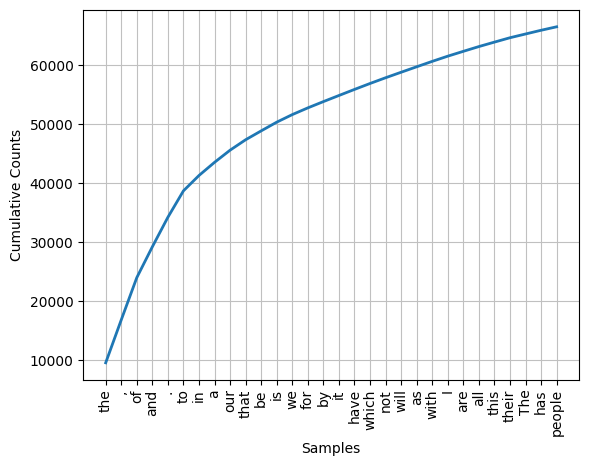

```python
fdist1.plot(30, cumulative=True)
```

**Conditional Frequency Distribution:**  
Combines 2 or more frequncy distributions.

```python
#Check the relative frequency of: can, could, may, might, will, would, should
# in the Gutenburg Corpus
modals=['can','could','may','might','will','would','should']
cfd = nltk.ConditionalFreqDist(
  (text, word)
    for text in gb.fileids()
    for word in gb.words(text))
cfd.tabulate(conditions=titles, samples=modals)
```

```
                           can  could    may  might   will  would should
        austen-emma.txt    270    825    213    322    559    815    366
  austen-persuasion.txt    100    444     87    166    162    351    185
       austen-sense.txt    206    568    169    215    354    507    228
          bible-kjv.txt    213    165   1024    475   3807    443    768
        blake-poems.txt     20      3      5      2      3      3      6
     bryant-stories.txt     75    154     18     23    144    110     38
burgess-busterbrown.txt     23     56      3     17     19     46     13
      carroll-alice.txt     57     73     11     28     24     70     27
    chesterton-ball.txt    131    117     90     69    198    139     75
   chesterton-brown.txt    126    170     47     71    111    132     56
chesterton-thursday.txt    117    148     56     71    109    116     54
  edgeworth-parents.txt    340    420    160    127    517    503    271
 melville-moby_dick.txt    220    215    230    183    379    421    181
    milton-paradise.txt    107     62    116     98    161     49     55
 shakespeare-caesar.txt     16     18     35     12    129     40     38
 shakespeare-hamlet.txt     33     26     56     28    131     60     52
shakespeare-macbeth.txt     21     15     30      5     62     42     41
     whitman-leaves.txt     88     49     85     26    261     85     42
```

Note below we reference the "raw" text of the book which is NOT split up into tokens. The raw() function gives us the contents of the file without any linguistic processing.  
len(gutenberg.raw('blake-poems.txt')) provides how many letters occur in the text including spaces between words.  
The sents() function divides the text up into its sentences, where each sentence is a list of words.

```python
import pandas as pd
np_object=[]
for fileid in gb.fileids():
    num_chars = len(gb.raw(fileid))
    num_words = len(gb.words(fileid))
    num_sents = len(gb.sents(fileid))
    num_vocab = len(set(w.lower() for w in gb.words(fileid)))
    x= [fileid, round(num_chars/num_words), round(num_words/num_sents), round(num_words/num_vocab)]
    np_object.append(x)
#PUT DATA in DataFrame and fancy up columns and row headings
df= pd.DataFrame(np_object, columns=['Title', '#chars/#words', '#words/#sents', '#words/#vocab'])
```

```python
print(df)
```

```
                      Title  #chars/#words  #words/#sents  #words/#vocab
0           austen-emma.txt              5             25             26
1     austen-persuasion.txt              5             26             17
2          austen-sense.txt              5             28             22
3             bible-kjv.txt              4             34             79
4           blake-poems.txt              5             19              5
5        bryant-stories.txt              4             19             14
6   burgess-busterbrown.txt              4             18             12
7         carroll-alice.txt              4             20             13
8       chesterton-ball.txt              5             20             12
9      chesterton-brown.txt              5             23             11
10  chesterton-thursday.txt              5             18             11
11    edgeworth-parents.txt              4             21             25
12   melville-moby_dick.txt              5             26             15
13      milton-paradise.txt              5             52             11
14   shakespeare-caesar.txt              4             12              9
15   shakespeare-hamlet.txt              4             12              8
16  shakespeare-macbeth.txt              4             12              7
17       whitman-leaves.txt              5             36             12
```

A concordance view shows us every occurrence of a given word along with some context.  
Note: The 1st time you use a concordance on a particular text, it takes a few extra seconds to build an index so that subsequent searches are fast.  
Use:  
**.concordance**

```python
#text1: Moby Dick by Herman Melville 1851
text1.concordance("cannibal")
```

```
Displaying 19 of 19 matches:
azed , and wondered what monstrous cannibal and savage could ever have gone a
e holy Sabbath , engaged in such a cannibal business as selling the heads of d
t was extinguished , and this wild cannibal , tomahawk between his teeth , spr
 , I kill - e !" again growled the cannibal , while his horrid flourishings of
hat that infernal harpooneer was a cannibal ?" " I thought ye know ' d it ;--
the whole a clean , comely looking cannibal . What ' s all this fuss I have be
of him . Better sleep with a sober cannibal than a drunken Christian . " Landl
ge house in the broad day , with a cannibal and a tomahawk ! " Queequeg !-- in
h sadly vitiated , I fear , by the cannibal propensity he nourished in his unt
tain , " I ' ll kill - e YOU , you cannibal , if you try any more of your tric
 . She was a thing of trophies . A cannibal of a craft , tricking herself fort
 had not suspected my friend was a cannibal , and furthermore announcing that
that sight take a tooth out of the cannibal ' s jaw ? Cannibals ? who is not a
' s jaw ? Cannibals ? who is not a cannibal ? I tell you it will be more toler
to kindle a fire in this shivering cannibal ? Ginger !-- what the devil is gin
the Zodiac himself . What says the Cannibal ? As I live he ' s comparing notes
 they had been lost by some little cannibal urchins , the priest ' s children
tiered sharks , and thy kidnapping cannibal ways . Let faith oust fact ; let f
nd his mother tells him of me , of cannibal old me ; how I am abroad upon the
```

```python
#From the Book of Genesis
# How long people lived
text3.concordance("lived")
```

```
Displaying 25 of 38 matches:
ay when they were created . And Adam lived an hundred and thirty years , and be
ughters : And all the days that Adam lived were nine hundred and thirty yea and
nd thirty yea and he died . And Seth lived an hundred and five years , and bega
ve years , and begat Enos : And Seth lived after he begat Enos eight hundred an
welve years : and he died . And Enos lived ninety years , and begat Cainan : An
 years , and begat Cainan : And Enos lived after he begat Cainan eight hundred
ive years : and he died . And Cainan lived seventy years and begat Mahalaleel :
rs and begat Mahalaleel : And Cainan lived after he begat Mahalaleel eight hund
years : and he died . And Mahalaleel lived sixty and five years , and begat Jar
s , and begat Jared : And Mahalaleel lived after he begat Jared eight hundred a
and five yea and he died . And Jared lived an hundred sixty and two years , and
o years , and he begat Eno And Jared lived after he begat Enoch eight hundred y
 and two yea and he died . And Enoch lived sixty and five years , and begat Met
 ; for God took him . And Methuselah lived an hundred eighty and seven years ,
 , and begat Lamech . And Methuselah lived after he begat Lamech seven hundred
nd nine yea and he died . And Lamech lived an hundred eighty and two years , an
ch the LORD hath cursed . And Lamech lived after he begat Noah five hundred nin
naan shall be his servant . And Noah lived after the flood three hundred and fi
xad two years after the flo And Shem lived after he begat Arphaxad five hundred
at sons and daughters . And Arphaxad lived five and thirty years , and begat Sa
ars , and begat Salah : And Arphaxad lived after he begat Salah four hundred an
begat sons and daughters . And Salah lived thirty years , and begat Eber : And
y years , and begat Eber : And Salah lived after he begat Eber four hundred and
 begat sons and daughters . And Eber lived four and thirty years , and begat Pe
y years , and begat Peleg : And Eber lived after he begat Peleg four hundred an
```

Other words that appear in a similar range of context  
Use:  
**.similar**

```python
#text1: Moby Dick by Herman Melville 1851
text1.similar("monstrous")
```

```
true contemptible christian abundant few part mean careful puzzled
mystifying passing curious loving wise doleful gamesome singular
delightfully perilous fearless
```

```python
#text2: Sense and Sensibility by Jane Austen 1811
text2.similar("monstrous")
```

```
very so exceedingly heartily a as good great extremely remarkably
sweet vast amazingly
```

Examines just the contexts that are shared by two or more words.  
Use:  
**.common_contexts**

```python
text2.common_contexts(["monstrous", "very"])
```

```
am_glad a_pretty a_lucky is_pretty be_glad
```

Determines the location of a word in the text: how many words from the beginning it appears. This positional information can be displayed using a dispersion plot.

# Dispersion Plot:

Determines the location of a word in text. i.e, How many words from the beginning does it appear?  
This positional information can be displayed in a dispersion plot.  
Each stripe represents an instance of a word, and each row represents the entire text . Notice there will be some interesting patterns of word usage over the last 220 years.  
(in an artificial text constructed by joining the texts of the Inaugural Address Corpus end-to-end).

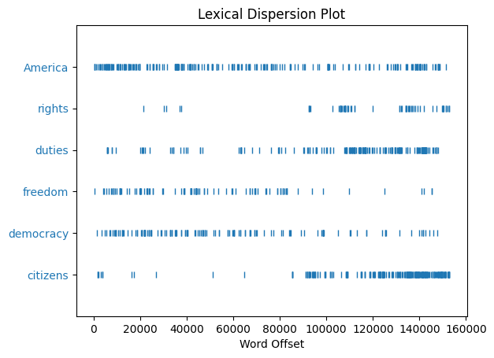

```python
#text4: Inaugural Address Corpus
text4.dispersion_plot(["citizens", "democracy", "freedom", "duties","rights", "America"])
```

Generate random text from corpus  
Use:  
**.generate**

```python
#text4: Inaugural Address Corpus
text4.generate()
```

```
Building ngram index...
```

```
objects , and especially the truth that democratic government has
innate capacity to govern its affairs aright through the Province
ceded , by any timid forebodings of evil were not to overtake them
while I possess the property of the pecuniary estimates for the
advancement of civilization . , religion and a reckless disregard of
the Argonne , Omaha Beach , Salerno and halfway around the globe , and
nothing is more important in the House and the special attention of
the Government to interfere with the advice and equipment to free ones
; to the public agents intrusted with
```

```
'objects , and especially the truth that democratic government has\ninnate capacity to govern its affairs aright through the Province\nceded , by any timid forebodings of evil were not to overtake them\nwhile I possess the property of the pecuniary estimates for the\nadvancement of civilization . , …
```

# Tokenization in NLTK

Breaking down documents, sentences, phrases into parts of speech  
1.Tokenize to sentences or words (nltk.word_tokenize or nltk.sent_tokenize)  
2.Tag Data – Determine parts of speech

```python
text = "Mr. Smith loves tacos. He has a Ph.D. in taco-ology."
```

```python
nltk.word_tokenize(text)
```

```
['Mr.',
 'Smith',
 'loves',
 'tacos',
 '.',
 'He',
 'has',
 'a',
 'Ph.D.',
 'in',
 'taco-ology',
 '.']
```

```python
tokenized_sentences = nltk.sent_tokenize(text)
for sent in tokenized_sentences:
    print("Sentence:")
    print(sent)
    print()
```

```
Sentence:
Mr. Smith loves tacos.

Sentence:
He has a Ph.D. in taco-ology.
```

```python
# notice that 'Mr.' is one token but 'disco.' and 'tacos.' are two tokens.
text2 = "Mr. Smith loves tacos. He has a Ph.D. in taco-ology."
tokens = nltk.word_tokenize(text2)
print(tokens)
```

```
['Mr.', 'Smith', 'loves', 'tacos', '.', 'He', 'has', 'a', 'Ph.D.', 'in', 'taco-ology', '.']
```

In the above taco-ology example NLTK recognizes that Mr. is not a sentence but a **single** token. Similarily, it does not break Ph.D. as sentences but treats it as a **single** token.

```python
#Download just the 'punkt' data set.
# 'punkt' is a pre-trained sentence tokenizer for English.
nltk.download('punkt')
```

```
True
```

```python
sent_detector = nltk.data.load('tokenizers/punkt/english.pickle')
```

```python
text = '''Punkt knows that the periods in Mr. Smith and Johann S. Bach do not mark sentence boundaries.  And sometimes sentences can start with non-capitalized words.  i is a good
variable name. '''
```

In the example above: Mr. Smith & Bach retain the whitespace from the original text including newlines in the output.  
Punctuation following sentences is also included by default (from NLTK 3.0 onwards). It can be excluded with the realign_boundaries flag.

```python
print('\n-----\n'.join(sent_detector.tokenize(text.strip())))
```

```
Punkt knows that the periods in Mr. Smith and Johann S. Bach do not mark sentence boundaries.
-----
And sometimes sentences can start with non-capitalized words.
-----
i is a good
variable name.
```

# Tagging

A part-of-speech (POS) tagger processes a sequence of words and attaches a part of speech tag to each word.

```python
text =  nltk.word_tokenize("And now for something completely different")
nltk.pos_tag(text)
```

```
[('And', 'CC'),
 ('now', 'RB'),
 ('for', 'IN'),
 ('something', 'NN'),
 ('completely', 'RB'),
 ('different', 'JJ')]
```

In above example...  
**Parts of Speech Tagging:** coordinating conjunction = cc (And)  
adverbs = RB (examples: now and completely)  
preposition = IN (example: for)  
noun = NN (example: something)  
adjective = jj (example: different)  
Note: NLTK provides documentation for each tag which can be queried using the tag, e.g. nltk.help.upenn_tagset('RB'), or a regular expression, e.g. nltk.help.upenn_tagset('NN.*')

```python
nltk.help.upenn_tagset('NN.*')
```

```
NN: noun, common, singular or mass
    common-carrier cabbage knuckle-duster Casino afghan shed thermostat
    investment slide humour falloff slick wind hyena override subhumanity
    machinist ...
NNP: noun, proper, singular
    Motown Venneboerger Czestochwa Ranzer Conchita Trumplane Christos
    Oceanside Escobar Kreisler Sawyer Cougar Yvette Ervin ODI Darryl CTCA
    Shannon A.K.C. Meltex Liverpool ...
NNPS: noun, proper, plural
    Americans Americas Amharas Amityvilles Amusements Anarcho-Syndicalists
    Andalusians Andes Andruses Angels Animals Anthony Antilles Antiques
    Apache Apaches Apocrypha ...
NNS: noun, common, plural
    undergraduates scotches bric-a-brac products bodyguards facets coasts
    divestitures storehouses designs clubs fragrances averages
    subjectivists apprehensions muses factory-jobs ...
```

**Stop words in NLTK**  
In old days we used to remove very frequent words without much sematic weight. We called those words "stop word".  
NLTK has a default set of stop words which you could change.

```python
# Note: "set" is fast
english_stopwords = set(nltk.corpus.stopwords.words('english'))
print(english_stopwords)
```

```
{'yourselves', 'than', "shouldn't", 're', 'do', 'until', 'only', 's', 'what', 'themselves', 'just', 'he', 'him', 'all', 'haven', 'have', 'once', 'most', 'hasn', "couldn't", 'can', 'shan', 'don', 'the', 'here', 'any', 'that', 'who', 'after', "didn't", 'an', 'she', 'herself', "hasn't", 'such', 'there'…
```

```python
spanish_stopwords = set(nltk.corpus.stopwords.words('spanish'))
print(spanish_stopwords)
```

```
{'vuestra', 'algo', 'mías', 'nada', 'he', 'ante', 'tu', 'tendré', 'habremos', 'hubisteis', 'ha', 'os', 'porque', 'hubiese', 'sentidos', 'seré', 'tiene', 'hubiera', 'estad', 'estabas', 'algunas', 'estuvierais', 'hubieseis', 'tengan', 'están', 'nos', 'las', 'sentida', 'seas', 'pero', 'tuvimos', 'nuest…
```

```python
# Here we remove stop words to get the gist of a sentence
from nltk.tokenize import word_tokenize
text = "The chicken went to the house to humiliate the man."
tokens = word_tokenize(text)
content_tokens = [token for token in tokens if token.lower() not in english_stopwords]
print(content_tokens)
```

```
['chicken', 'went', 'house', 'humiliate', 'man', '.']
```

```python
#Alternatively
from nltk.corpus import stopwords
from nltk import download
download('stopwords')  # Download stopwords list.

# Remove stopwords.
stop_words = stopwords.words('english')
```

**Load your own Corpus**  
-Tokenize words

To load a collection of text files  
Use:  
**PlaintextCorpusReader**

```python
#Hp1.txt = Harry Potter and the Sorcerer's Stone
# PlaintextCorpusReader is best for reading through many text files but
# has been modified for a simpler use case.
from nltk.corpus import PlaintextCorpusReader
corpus_root = '.'
wordlists = PlaintextCorpusReader(corpus_root, 'HP1.txt')  # replace 'HP1.txt' with ''*.txt'
(wordlists.fileids)
```

```
<bound method CorpusReader.fileids of <PlaintextCorpusReader in '/Users/shiveshrajsahu/Desktop/Cs767/cs767A1_SAHU_SHIVESH_HW09'>>
```

```python
sents = wordlists.sents("HP1.txt")
sents[1:10]
```

```
[['They',
  'were',
  'the',
  'last',
  'people',
  'you',
  "'",
  'd',
  'expect',
  'to',
  'be',
  'involved',
  'in',
  'anything',
  'strange',
  'or',
  'mysterious',
  ',',
  'because',
  'they',
  'just',
  'didn',
  "'",
  't',
  'hold',
  'with',
  'such',
  'nonsense',
  '.'],
 ['Mr',
  '.',
  'Dursley',
  'was',
  'the',
  'director',
  'of',
  'a',
  'firm',
  'called',
  'Grunnings',
```

[output cut: 187 more lines]

```
  'to',
  'think',
  'what',
  'the',
  'neighbors',
  'would',
  'say',
  'if',
  'the',
  'Potters',
  'arrived',
  'in',
  'the',
  'street',
  '.']]
```

```python
#Alternatively read file in using Python with open
with open('HP1.txt') as file_in:
    print(file_in.readlines())
```

```
['Mr. and Mrs. Dursley, of number four, Privet Drive, were proud to say that they were perfectly\n', "normal, thank you very much.  They were the last people you'd expect to be involved in anything\n", "strange or mysterious, because they just didn't hold with such nonsense. Mr. Dursley was the\n", …
```

```python
#Read text: J. K. Rowling - Harry Potter 1 - Harry Potter and the Sorcerer's Stone

def read_file():
    text = ''
    # The file is: 'HP1.txt'
    # called `corpus`
    with open('HP1.txt') as file_in:

        for line in file_in:
            print(line)
            text = text + line
    return text

# here we create a variable called book_content and make it equal to the value of the read_file function for book 1
book_content = read_file()
```

[output not shown]

[output cut: 470 more lines]

```
neat hedges of Privet Drive, which lay silent and tidy under the inky sky, the very last place you

would expect astonishing things to happen. Harry Potter rolled over inside his blankets without

waking up. One small hand closed on the letter beside him and he slept on, not knowing he was

special, not knowing he was famous, not knowing he would be woken in a few hours' time by Mrs.

Dursley's scream as she opened the front door to put out the milk bottles, nor that he would spend

the next few weeks being prodded and pinched by his cousin Dudley... He couldn't know that at this

very moment, people meeting in secret all over the country were holding up their glasses and saying

in hushed voices: "To Harry Potter -- the boy who lived!"
```

```python
#Tokenize all words
from nltk import word_tokenize

def tokenize_lower_text(book_content):
    tokenized = nltk.word_tokenize(book_content)
    tokenized = [word.lower() for word in tokenized]
    return tokenized

tokenized = tokenize_lower_text(book_content)
```

```python
print(tokenized[33746:33800])
```

```
[]
```

```python
#Separate into sentences
tokenized_sentences = nltk.sent_tokenize(book_content)
print(tokenized_sentences)
```

```
['Mr. and Mrs. Dursley, of number four, Privet Drive, were proud to say that they were perfectly\nnormal, thank you very much.', "They were the last people you'd expect to be involved in anything\nstrange or mysterious, because they just didn't hold with such nonsense.", 'Mr. Dursley was the\ndirect…
```

```python
#Separate into words
nltk.word_tokenize(book_content)
```

```
['Mr.',
 'and',
 'Mrs.',
 'Dursley',
 ',',
 'of',
 'number',
 'four',
 ',',
 'Privet',
 'Drive',
 ',',
 'were',
 'proud',
 'to',
 'say',
 'that',
 'they',
 'were',
 'perfectly',
 'normal',
 ',',
 'thank',
 'you',
 'very',
 'much',
 '.',
 'They',
 'were',
 'the',
 'last',
 'people',
 'you',
 "'d",
 'expect',
 'to',
 'be',
 'involved',
 'in',
 'anything',
```

[output cut: 946 more lines]

```
 'bun',
 'from',
 'the',
 'bakery',
 '.',
 'He',
 "'d",
 'forgotten',
 'all',
 'about',
 'the',
 'people',
 'in',
 'cloaks',
 ...]
```